# MultiONet Analysis Workflow

2025-06-09

# 1 Introduction

This vignette demonstrates the workflow using the **MultiONet** R package, specifically designed for network-based multi-omics integration and enrichment analyses. We will apply it to kidney data from Maximilian Reck et al. (Nature Communications, 2025) to explore the functionality of MultiONet.

## 1.1 Required Packages

Install and load necessary libraries:

```r
library(dplyr)
library(magrittr)
library(MultiONet)
library(OmnipathR)
library(igraph)
library(GGally)
```

# 2 Workflow

Define target clusters and initialize variables:

```r
target_clusters <- c("PT Injured", "PT Inflammatory")
cluster_a <- target_clusters[1]
```

# 3 Data Preparation

Subset your DEG and peak data based on selected clusters:

```r
data_a <- deg %>% filter(Cluster == cluster_a, adj..p.value < 0.05)
data_b <- peak %>% filter(Cluster == cluster_a, adj..p.value < 0.05)
```

# 4 Gene Set Enrichment Analysis (ORA)

Run overrepresentation analysis (ORA) on DEGs, peak genes, their intersection, and their union.

```r
Largest_of_deg_ora <- run_ora(data_a$Gene)
Largest_of_peak_ora <- run_ora(data_b$Closest.Gene)
Largest_of_intersection_ora <- run_ora(intersect(data_a$Gene, data_b$Closest.Gene))
Largest_of_combined_ora <- run_ora(union(data_a$Gene, data_b$Closest.Gene))
```

Examine the dimensions of the results:

```r
dim(Largest_of_deg_ora)
```

```
## [1] 140  12
```

```r
dim(Largest_of_peak_ora)
```

```
## [1] 25 12
```

```r
dim(Largest_of_intersection_ora)
```

[output not shown]

```r
dim(Largest_of_combined_ora)
```

```
## [1] 148  12
```

# 5 Compare Gene Lists

Compare DEG and peak gene lists to identify overlaps and differences. There is 8% overlap between the two gene sets.

```r
input <- list(deg = data_a$Gene, peak = data_b$Closest.Gene)
result <- compare_gene_list(input)
```

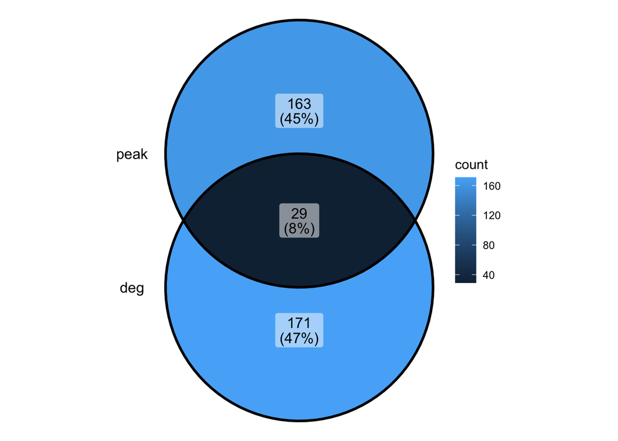

# 6 Network Generation

Create networks based on the gene lists. Networks can be constructed from (i) differentially expressed genes (DEGs), (ii) genes associated with peaks, (iii) their intersection, and (iv) their union. For each case, the largest connected subnetwork can also be extracted.

```
## Processing deg ...
```

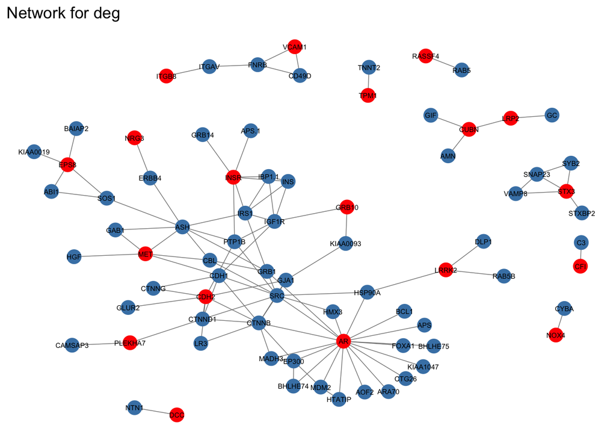

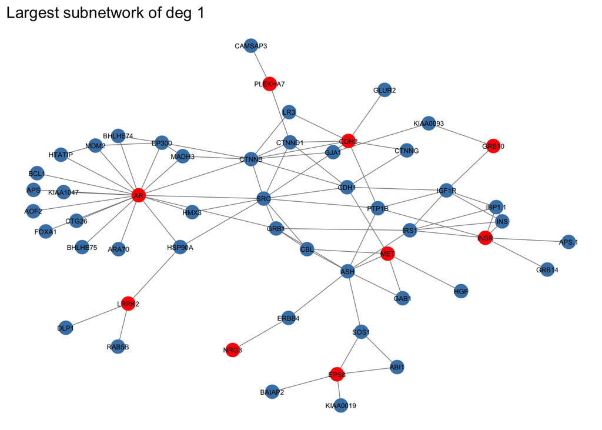

```
## Processing peak ...
```

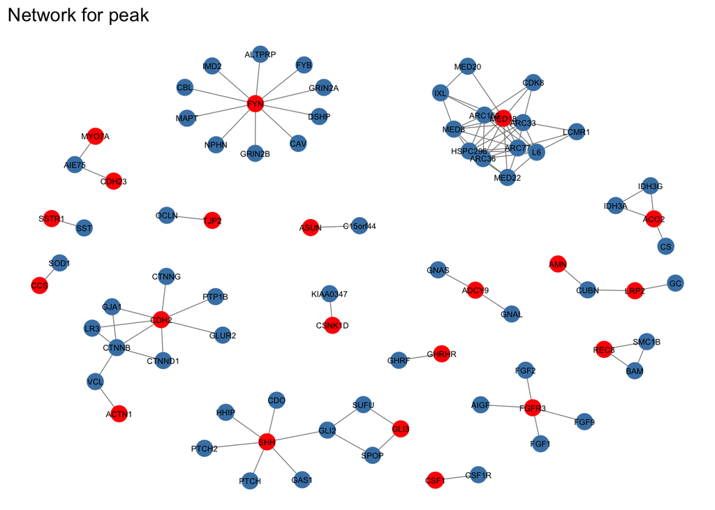

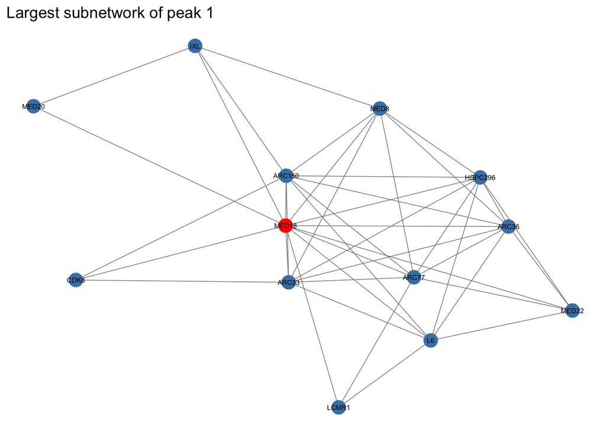

```
## Processing intersection ...
```

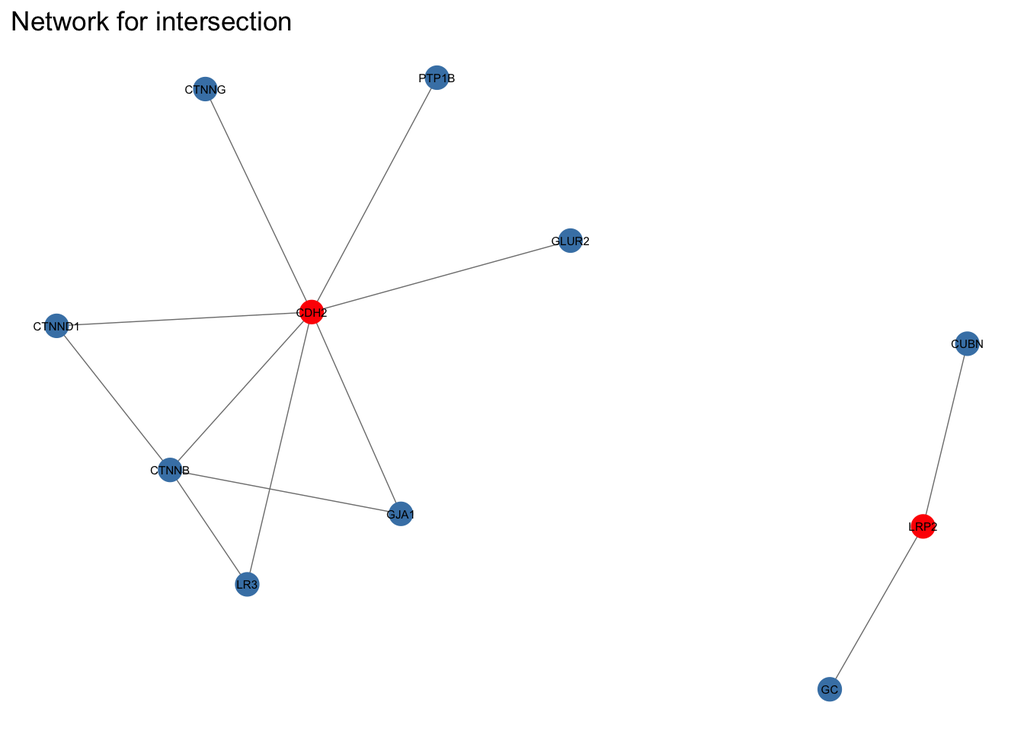

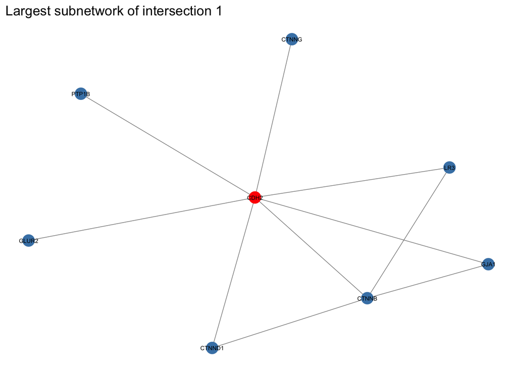

```
## Processing combined ...
```

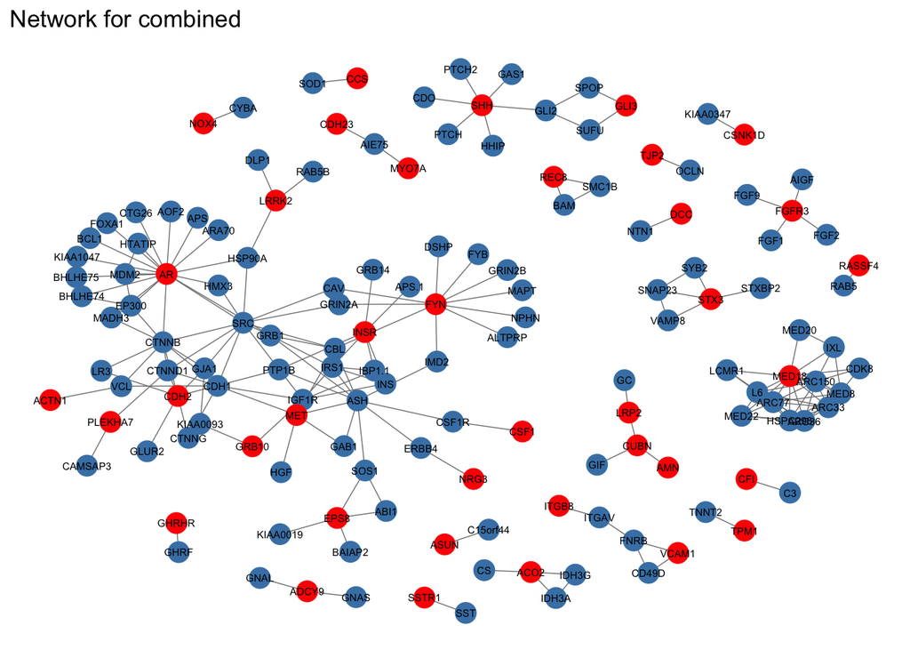

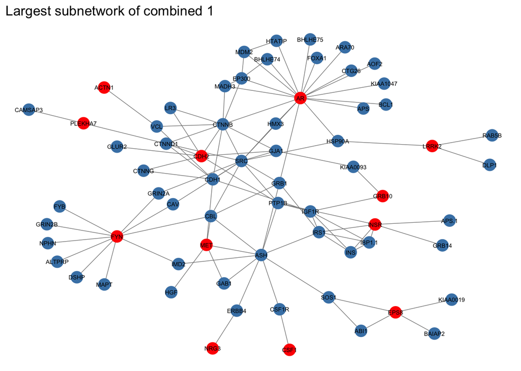

```
##                                Network Node_Count Edge_Count
## deg                   Network from deg         78        108
## peak                 Network from peak         80         99
## intersection Network from intersection         11         12
## combined         Network from combined        145        199
##                                                             Network Node_Count
## Largest_network_of_deg_1                   Largest_network_of_deg_1         53
## Largest_network_of_peak_1                 Largest_network_of_peak_1         13
## Largest_network_of_intersection_1 Largest_network_of_intersection_1          8
## Largest_network_of_combined_1         Largest_network_of_combined_1         67
##                                   Edge_Count
## Largest_network_of_deg_1                  88
## Largest_network_of_peak_1                 42
## Largest_network_of_intersection_1         10
## Largest_network_of_combined_1            106
## Node Intersections:
##              deg peak intersection combined
## deg            0   13           11       78
## peak           0    0           11       80
## intersection   0    0            0       11
## combined       0    0            0        0
##
## Edge Intersections:
##              deg peak intersection combined
## deg            0   13           12      108
## peak           0    0           12       99
## intersection   0    0            0       12
## combined       0    0            0        0
```

```r
setwd(paste0(mypath,"/data"))

result <- make_networks(
  input,
  indirect_neighbors = 1,
  score_threshold = 996,
  network_file_prefix = cluster_a,
  string_link_file = "9606.protein.links.full.v11.5.txt.gz",
  string_alias_file = "9606.protein.aliases.v11.5.txt.gz",
  plot_network = TRUE,
  label_genes = TRUE,
  plot_network_node_threshold = 2000,
  label_size = 2
)
```

# 7 ORA of Largest Networks

Perform ORA for genes in the largest networks then plot a upset plot to examine the similarity between the two results.:

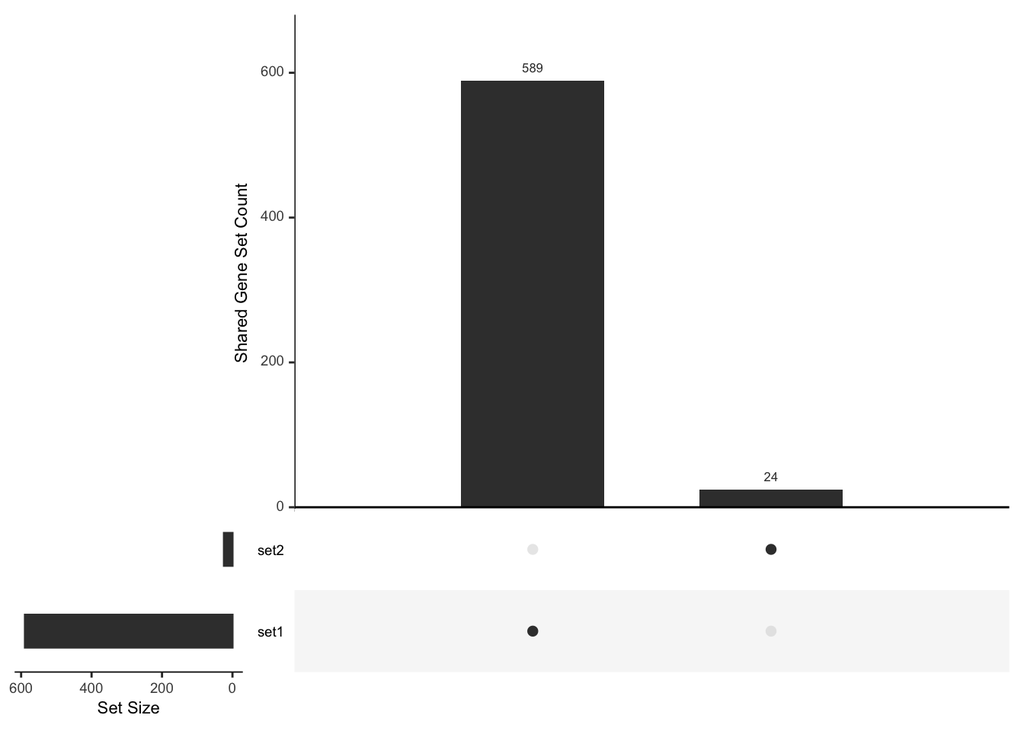

```r
Largest_network_of_deg_ora <- run_ora(V(result[['largest_networks']][["Largest_network_of_deg_1"]])$name)
Largest_network_of_peak_ora <- run_ora(V(result[['largest_networks']][["Largest_network_of_peak_1"]])$name)

compare_gene_sets(list(set1 = Largest_network_of_deg_ora, set2 = Largest_network_of_peak_ora))
```

# 8 Reducing Enrichment Results

Reduce redundancy in enrichment results using semantic similarity. The returned matrix has parent node information that can be used to remove duplicate results:

```r
Largest_network_of_deg_ora %<>% mutate(source = "deg")
Largest_network_of_peak_ora %<>% mutate(source = "peak")

combined_raw <- rbind(Largest_network_of_deg_ora, Largest_network_of_peak_ora)
Largest_network_of_deg_peak_ora_reduced <- reduce_enrichment_result(combined_raw)
Largest_network_of_deg_ora_reduced <- reduce_enrichment_result(Largest_network_of_deg_ora)
Largest_network_of_peak_ora_reduced <- reduce_enrichment_result(Largest_network_of_peak_ora)

head(knitr::kable(Largest_network_of_peak_ora_reduced))
```

[output not shown]

# 9 Heatmap Visualization

Create a heatmap to visualize reduced enrichment results. Heatmap is based on top 20 gene sets from each gene set results (DEG & peak). The common parents between the two gene sets and the unique parents of each gene set are kept in the result:

```r
reduced_heatmap_r <- reduced_heatmap(
  Largest_network_of_deg_peak_ora_reduced[['processed_result']],
  combined_raw,
  Largest_network_of_deg_ora_reduced[['processed_result']],
  Largest_network_of_peak_ora_reduced[['processed_result']],
  file_name="GSE254185_kidney",
  max_per_set = 20
)
```

[output not shown]

[output cut: 91 more lines]

[output not shown]

```r
knitr::include_graphics(paste0(mypath,"/scripts/GSE254185_kidney.pdf"))
```

[figure not shown]

# 10 Directed Network Visualization

Visualize directed networks with Omnipath, a database built from above 100 resources:

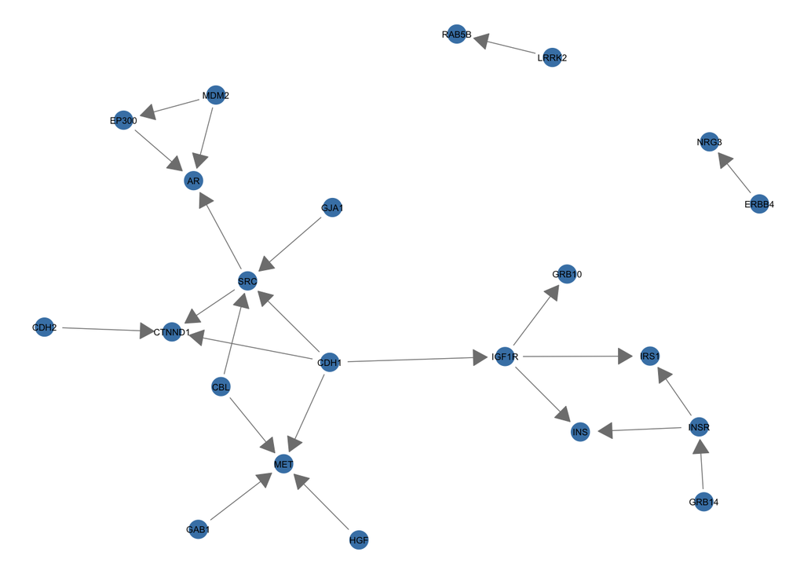

```r
make_directed_graph(result[['largest_networks']][["Largest_network_of_deg_1"]])
```

```r
make_directed_graph(result[['largest_networks']][["Largest_network_of_peak_1"]])
```

```
## [1] "There is no direction assgiend to edges"
```

# 11 Centrality Analysis (PageRank)

Calculate and visualize PageRank to identify influential nodes:

```r
pagerank_result <- get_pagerank(result[['largest_networks']][["Largest_network_of_combined_1"]])
```

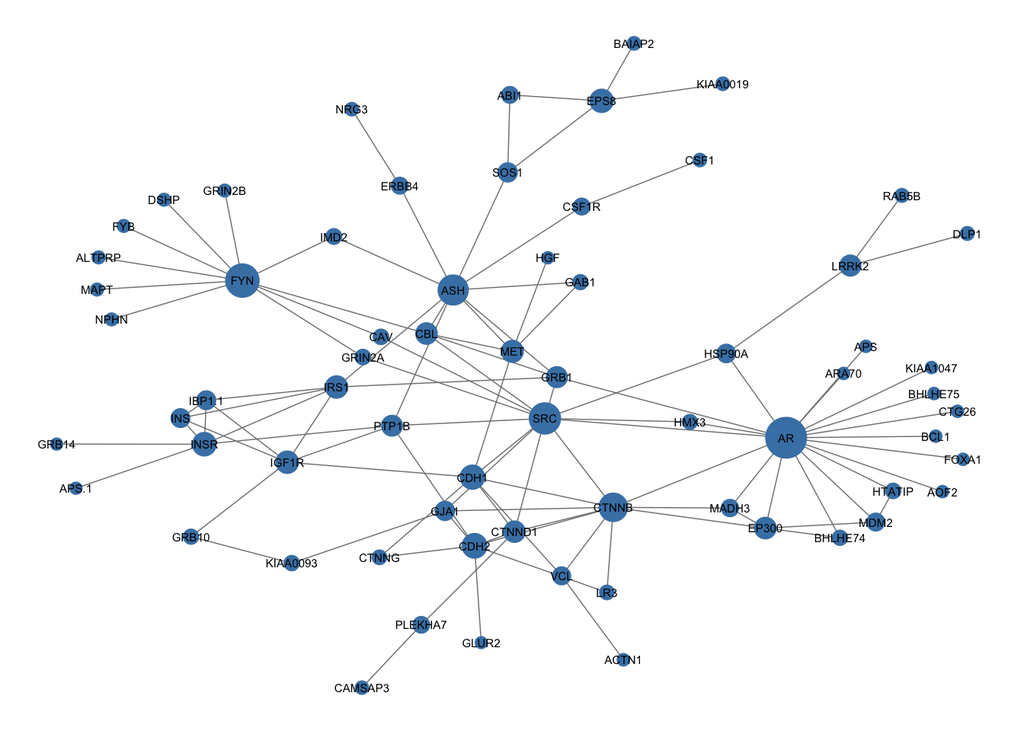

# 12 Conclusion

This vignette illustrates the use of **MultiONet** to systematically analyze and visualize multi-omics data, enabling comprehensive biological insights through integrated network and enrichment analyses.